# More Linear Programming Examples

Freddy R. Drennan

September 11, 2016

# Problem 1:

**Max is eating in a pie eating contest that lasts one hour. Each torte that he eats takes 2 minutes. Each apple pie that he eats takes 3 minutes. He receives 4 points for each torte and 5 points for each pie. What should max eat so as to get the most points? Solve the problem using the graphical method.**

The formula here is plotted below and consists of the blue shaded area:
$$\text{tortes} \leq \frac{60min - 3pie}{2}$$

The black lines are isoprofit lines that follow the formula:

$$T = torte \\$$
$$P = pie \\$$
$$4\frac{\text{dollars}}{\text{torte}}T +
5\frac{\text{dollars}}{\text{pie}}P$$

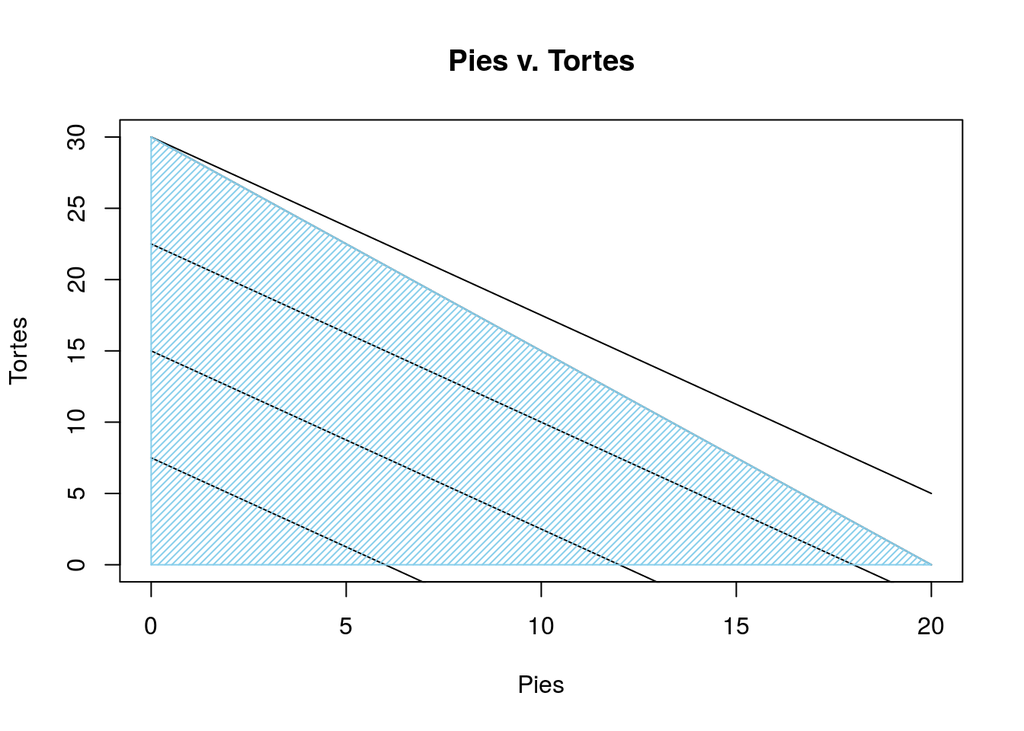

```r
curve((60-3*x)/2, xlim = c(0, 20), ylab = "Tortes", xlab = "Pies", main="Pies v. Tortes")

for (profit in 1:4*30) {
curve(((profit)-5*x)/4, add=TRUE)
}

polygon(c(0,0,20), c(0, 30, 0), col = 'skyblue',density = 30, fillOddEven = TRUE)
```

We can see that when $profit = 120$ the isoprofit line is equal with the constraints given so tortes will equal 30 and pies 0 for a total profit of 120. This works because 30 tortes times 2 minutes per torte equals 60 minutes.

**Next, let’s see what happens if he would like to stick to his preference of eating at least as many pies as tortes. That is, the number of pies he eats should be greater than or equal to the number of tortes. By how many points does this constraint decrease Max’s total points?**

We’ll now add the following constraint seen in red.
$$\text{pies} - \text{tortes} \geq 0$$

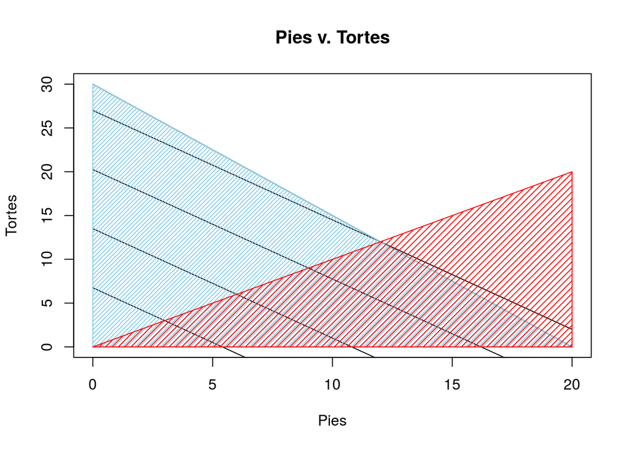

Now, the max profit is 108 dollars and given that the isoprofit line is on the line where tortes equal pies, we can use the formula below to determine the number of tortes and pies consumed. Or we can simply use the for loop to find where the isoprofit line maximizes all of the constraints given.

$$4\: tortes + 5\: pies = 108\: dollars \\$$
$$number\: of\: tortes = number\: of\: pies \\$$
$$4(12)+5(12)=108$$

# Problem 2

**A farmer in Iowa owns 450 acres of land. He is going to plant each acre with wheat or corn. Each acre planted with wheat yields $2,000 profit, requires three workers, and requires two tons of fertilizer. Each acre planted with corn yields $3,000 profit, requires two workers, and requires four tons of fertilizer. There are currently 1,000 workers and 1,200 tons of fertilizer available.**

- **Formulate the optimization problem and solve the problem graphically.**

$$x_1 = wheat \\$$
$$x_2 = corn \\$$
$$\text{workers constraint}\;\;\;3x_1 + 2x_2 \leq 1000 \\$$
$$\text{fertilizer constraint}\;\;\;2x_1 4x_2 \leq 1200$$

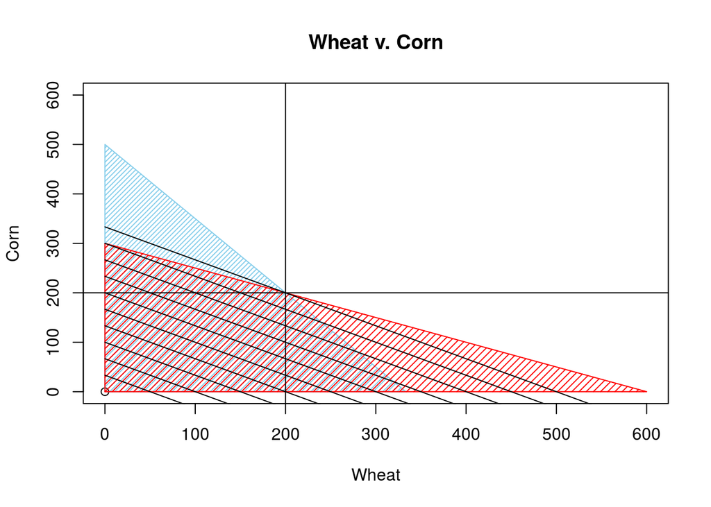

```r
# Here we can set x1 and x2 for the different equations to 0 and solve to
# find their respective intercepts.
plot(0,0, xlim = c(0, 600), ylim = c(0, 600), xlab = "Wheat", ylab = "Corn",
     main="Wheat v. Corn")

polygon(c(0, 1000/3, 0), c(500, 0, 0), col = "skyblue", density = 30)
polygon(c(0, 1200/2, 0), c(1200/4, 0, 0), col = "red", density = 20)

abline(h=200, v = 200)


for (profit in 1:10*100000) {
curve(((profit)-2000*x)/3000, add=TRUE)
}
```

We can visualize here that the maximium profit will be when corn equals 200 and wheat equals 200. Now, lets try to do the same in R.

- **Solve the problem in R and verify that the solutions are the same.**

```r
library(lpSolve)
c <- c(2000, 3000)
A <- matrix(c(3, 2, 2, 4), nrow = 2)
b <- c(1000, 1200)
dir <- rep("<=", 2)
s = lp("max", c, A, dir, b)
s$solution
```

```
## [1] 200 200
```

- **What happens to the decision variables and the total profit when the availability of fertilizer varies from 200 tons to 2200 tons in 100-ton increments? When does the farmer discontinue producing wheat? When does he discontinue producing corn? How does the profit change for each 10-ton increment?**

The new system of equations is as follows.
$$3x_1 + 2x_2 \leq 1000 \\
2x_1 + 4x_2 \leq 200 \\$$

Next, we have to consider the issue above which states that fertilizer varies in 100-ton increments. We might have to reformulate our model, adjust it, as we go along to compensate for this issue.

```r
library(calibrate)
```

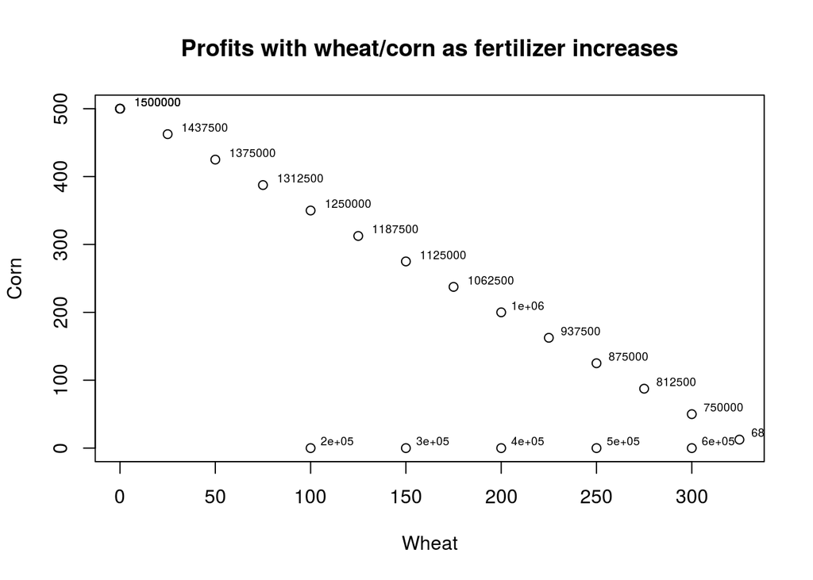

```r
i <- 200
n <- 1
fertilizerIndex <- NA
solution <- data.frame("wheat" = NA, "corn" = NA)
while(i <= 2200) {
c <- c(2000, 3000)
A <- matrix(c(3, 2, 2, 4), nrow = 2)
b <- c(1000, i)
dir <- rep("<=", 2)
s = lp("max", c, A, dir, b)
solution <- rbind(solution, s$solution)
fertilizerIndex[n] <- i
i <- i + 100
n <- n+1
}

solution$profit <- solution[,1]*2000 + solution[,2]*3000
solution <- solution[2:22,]
plot(solution$wheat, solution$corn, xlab = "Wheat", ylab = "Corn", main =
        "Profits with wheat/corn as fertilizer increases")
textxy(solution$wheat, solution$corn, solution$profit, cex = .60)
```

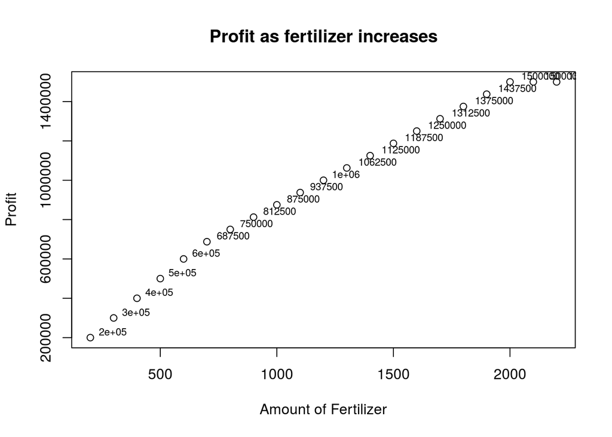

```r
plot(fertilizerIndex, solution$profit, xlab="Amount of Fertilizer", ylab =
        "Profit", main = "Profit as fertilizer increases")
textxy(fertilizerIndex, solution$profit, solution$profit, cex=.7)
```

```r
solution$fertilizer <- fertilizerIndex
solution
```

```
##    wheat  corn  profit fertilizer
## 2    100   0.0  200000        200
## 3    150   0.0  300000        300
## 4    200   0.0  400000        400
## 5    250   0.0  500000        500
## 6    300   0.0  600000        600
## 7    325  12.5  687500        700
## 8    300  50.0  750000        800
## 9    275  87.5  812500        900
## 10   250 125.0  875000       1000
## 11   225 162.5  937500       1100
## 12   200 200.0 1000000       1200
## 13   175 237.5 1062500       1300
## 14   150 275.0 1125000       1400
## 15   125 312.5 1187500       1500
## 16   100 350.0 1250000       1600
## 17    75 387.5 1312500       1700
## 18    50 425.0 1375000       1800
## 19    25 462.5 1437500       1900
## 20     0 500.0 1500000       2000
## 21     0 500.0 1500000       2100
## 22     0 500.0 1500000       2200
```

# Problem 3

**Star Oil Company is considering five different investment opportunities. The cash out-flows and net present values (in millions of dollars) are given in the table below. Star Oil has $40 million available for investment now (time 0); it estimates that one year from now (time 1) $20 million will be available for investment. Star Oil may purchase any fraction (less than or equal to 1) of each investment. In this case, the cash outflows and NPV are adjusted accordingly. For example, if Star Oil purchases one-fifth of investment 3, then a cash outflow of (1/5)5 = $1 million would be required at time 0, and a cash outflow of (1/5)5 = $1 million would be required at time 1. The one-fifth share of investment 3 would yield an NPV of (1/5)16 = $3.2 million. Star Oil wants to maximize the NPV that can be obtained by investing in investments 1-5. Formulate an LP that will help achieve this goal. Assume that any funds leftover at time 0 cannot be used at time 1.**

**Investment ($)**

| Cash Flows and NPV | 1 | 2 | 3 | 4 | 5 |
| --- | --- | --- | --- | --- | --- |
| Time 0 cash outflow | 11 | 53 | 5 | 5 | 29 |
| Time 1 cash outflow | 3 | 6 | 5 | 1 | 34 |
| NPV | 13 | 16 | 16 | 14 | 39 |

$$11x_1 + 53x_2 + 5x_3 + 5x_4 + 29x_5 \leq 40 \\$$
$$3x_1 + 6x_2 + 5x_3 + 1x_4 + 34x_5 \leq 20 \\$$

```r
c <- c(13, 16, 16, 14, 39)
A <- matrix(c(11, 53, 5, 5, 29, 3, 6, 5, 1, 34), nrow = 2, byrow=TRUE)
b <- c(40, 20)
dir <- rep("<=", 2)
s = lp("max", c, A, dir, b)
s$solution
```

```
## [1] 0 0 3 5 0
```